# Laboratorio 2 - Alan Hurtarte

## 19000590

## Variables

- **datetime** - hourly date + timestamp
- **season** - 1 = spring, 2 = summer, 3 = fall, 4 = winter
- **holiday** - whether the day is considered a holiday
- **workingday** - whether the day is neither a weekend nor holiday
- **weather** -
- 1: Clear, Few clouds, Partly cloudy, Partly cloudy
- 2: Mist + Cloudy, Mist + Broken clouds, Mist + Few clouds, Mist
- 3: Light Snow, Light Rain + Thunderstorm + Scattered clouds, Light Rain + Scattered clouds
- 4: Heavy Rain + Ice Pallets + Thunderstorm + Mist, Snow + Fog
- **temp** - temperature in Celsius
- **atemp** - “feels like” temperature in Celsius
- **humidity** - relative humidity
- **windspeed** - wind speed
- **casual** - number of non-registered user rentals initiated
- **registered** - number of registered user rentals initiated
- **count** - number of total rentals

```r
dataset<-read.csv('demandaBicis.csv', encoding = 'UTF-8')
dataset
```

| instant | dteday | season | yr | mnth | hr | holiday | weekday | workingday | weathersit | temp | atemp | hum | windspeed | casual | registered | cnt |
| --- | --- | --- | --- | --- | --- | --- | --- | --- | --- | --- | --- | --- | --- | --- | --- | --- |
| 1 | 2011-01-01 | 1 | 0 | 1 | 0 | 0 | 6 | 0 | 1 | 0.24 | 0.2879 | 0.81 | 0.0000 | 3 | 13 | 16 |
| 2 | 2011-01-01 | 1 | 0 | 1 | 1 | 0 | 6 | 0 | 1 | 0.22 | 0.2727 | 0.80 | 0.0000 | 8 | 32 | 40 |
| 3 | 2011-01-01 | 1 | 0 | 1 | 2 | 0 | 6 | 0 | 1 | 0.22 | 0.2727 | 0.80 | 0.0000 | 5 | 27 | 32 |
| 4 | 2011-01-01 | 1 | 0 | 1 | 3 | 0 | 6 | 0 | 1 | 0.24 | 0.2879 | 0.75 | 0.0000 | 3 | 10 | 13 |
| 5 | 2011-01-01 | 1 | 0 | 1 | 4 | 0 | 6 | 0 | 1 | 0.24 | 0.2879 | 0.75 | 0.0000 | 0 | 1 | 1 |
| 6 | 2011-01-01 | 1 | 0 | 1 | 5 | 0 | 6 | 0 | 2 | 0.24 | 0.2576 | 0.75 | 0.0896 | 0 | 1 | 1 |
| 7 | 2011-01-01 | 1 | 0 | 1 | 6 | 0 | 6 | 0 | 1 | 0.22 | 0.2727 | 0.80 | 0.0000 | 2 | 0 | 2 |
| 8 | 2011-01-01 | 1 | 0 | 1 | 7 | 0 | 6 | 0 | 1 | 0.20 | 0.2576 | 0.86 | 0.0000 | 1 | 2 | 3 |
| 9 | 2011-01-01 | 1 | 0 | 1 | 8 | 0 | 6 | 0 | 1 | 0.24 | 0.2879 | 0.75 | 0.0000 | 1 | 7 | 8 |
| 10 | 2011-01-01 | 1 | 0 | 1 | 9 | 0 | 6 | 0 | 1 | 0.32 | 0.3485 | 0.76 | 0.0000 | 8 | 6 | 14 |

[output cut: 9990 more lines]

## 1.- ¿Que mes es el que tiene la mayor demanda?

```r
Sub1.dataset <- dataset %>%
  select(dteday, casual, registered, cnt) %>%
  mutate(Date = format(as.Date(dteday), "%m-%Y")) %>%
    group_by(Date) %>%
      summarise(Casual = sum(casual), Registered = sum(registered), Total = sum(cnt)) %>%
        arrange(-Total)

Sub1.dataset
```

| Date | Casual | Registered | Total |
| --- | --- | --- | --- |
| 09-2012 | 43778 | 174795 | 218573 |
| 08-2012 | 43197 | 171306 | 214503 |
| 07-2012 | 41705 | 161902 | 203607 |
| 06-2012 | 43294 | 159536 | 202830 |
| 10-2012 | 34538 | 164303 | 198841 |
| 05-2012 | 44235 | 151630 | 195865 |
| 04-2012 | 38456 | 135768 | 174224 |
| 03-2012 | 31618 | 133257 | 164875 |
| 11-2012 | 21009 | 131655 | 152664 |
| 06-2011 | 30612 | 112900 | 143512 |

[output cut: 14 more lines]

### Respuesta

`El mes con mayor es demanda es septiembre del 2012 (9/2012)`

## 2.- ¿Que rango de hora es la de mayor demanda?

```r
Sub2.dataset <- dataset %>%
  select(dteday ,hr, casual, registered, cnt) %>%
    group_by(hr) %>%
      summarise(Casual = sum(casual), Registered = sum(registered), Total = sum(cnt)) %>%
        arrange(-Total)
Sub2.dataset
```

| hr | Casual | Registered | Total |
| --- | --- | --- | --- |
| 17 | 54220 | 282640 | 336860 |
| 18 | 44496 | 265276 | 309772 |
| 8 | 15761 | 245240 | 261001 |
| 16 | 53834 | 173914 | 227748 |
| 19 | 35505 | 191284 | 226789 |
| 13 | 52713 | 132206 | 184919 |
| 12 | 49718 | 134696 | 184414 |
| 15 | 54606 | 128543 | 183149 |
| 14 | 55089 | 120563 | 175652 |
| 20 | 26378 | 138172 | 164550 |

[output cut: 14 more lines]

### Respuesta

`Como se puede observar en la tabla superior el rango con mayor demandas es de 17 a 18 horas, con un rango de demanda (309772, 336860)`

## 3.- ¿Que temporada es la mas alta?

```r
Sub3.dataset <- dataset %>%
  select(season, casual, registered, cnt) %>%
    mutate(Season = case_when(season == 1 ~ 'Spring',
        season == 2 ~ 'Summer',
        season == 3 ~ 'Fall',
        season == 4 ~ 'Winter')) %>%
      group_by(Season) %>%
        summarise(Casual = sum(casual), Registered = sum(registered), Total = sum(cnt)) %>%
          arrange(-Total)
Sub3.dataset
```

| Season | Casual | Registered | Total |
| --- | --- | --- | --- |
| Fall | 226091 | 835038 | 1061129 |
| Summer | 203522 | 715067 | 918589 |
| Winter | 129782 | 711831 | 841613 |
| Spring | 60622 | 410726 | 471348 |

### Respuesta

`La temporada con mas demanda es Fall con 1061129. Se puede apreciar mejor con la grafica del inciso 8`

## 4.- ¿A que temperatura baja la demanda?

```r
Sub4.dataset <- dataset %>%
  select(temp, atemp, casual, registered, cnt) %>%
    mutate(Temp = ((temp + atemp) / 2)*100 ) %>%
      group_by(Temp) %>%
        summarise(Casual = sum(casual), Registered = sum(registered), Total = sum(cnt)) %>%
          arrange(Total)
Sub4.dataset
```

| Temp | Casual | Registered | Total |
| --- | --- | --- | --- |
| 4.275 | 0 | 1 | 1 |
| 2.515 | 0 | 2 | 2 |
| 78.395 | 1 | 6 | 7 |
| 7.030 | 0 | 9 | 9 |
| 2.000 | 3 | 9 | 12 |
| 1.760 | 0 | 13 | 13 |
| 79.150 | 0 | 14 | 14 |
| 4.790 | 0 | 15 | 15 |
| 7.275 | 0 | 15 | 15 |
| 6.275 | 0 | 24 | 24 |

[output cut: 284 more lines]

### Respuesta

`Si se toma el supuesto que una demanda baja sea menor a 100. La demanda es significativamente baja cuando hay mucho calor o mucho frio, por ejemplo debajo de 20ª o arriba de 40ª`

## 5.- ¿A que humedad baja la demanda?

```r
Sub5.dataset <- dataset %>%
  select(hum, casual, registered, cnt) %>%
    group_by(hum) %>%
      summarise(Casual = sum(casual), Registered = sum(registered), Total = sum(cnt)) %>%
        arrange(Total)
Sub5.dataset
```

| hum | Casual | Registered | Total |
| --- | --- | --- | --- |
| 0.13 | 3 | 14 | 17 |
| 0.12 | 6 | 23 | 29 |
| 0.14 | 10 | 28 | 38 |
| 0.97 | 18 | 46 | 64 |
| 0.08 | 16 | 61 | 77 |
| 0.10 | 19 | 88 | 107 |
| 0.91 | 7 | 112 | 119 |
| 0.92 | 9 | 143 | 152 |
| 0.15 | 116 | 176 | 292 |
| 0.96 | 8 | 367 | 375 |

[output cut: 79 more lines]

### Respuesta

`Si se toma el supuesto que una demanda baja sea menor a 100. Con la humedad abajo de 0.1 baja significativamente a 100 la demanda`

## 6.- ¿Que condiciones serian ideales para nuestra demanda?

```r
getmode <- function(v) {
 uniqv <- unique(v)
 uniqv[which.max(tabulate(match(v, uniqv)))]
}
Sub6.dataset.al <- dataset %>%
  select(season, temp, hr, weekday, cnt,weathersit) %>%
    filter(cnt > 700)
Sub6.dataset.al
```

| season | temp | hr | weekday | cnt | weathersit |
| --- | --- | --- | --- | --- | --- |
| 1 | 0.60 | 18 | 1 | 712 | 2 |
| 1 | 0.70 | 18 | 2 | 734 | 1 |
| 1 | 0.70 | 17 | 3 | 782 | 1 |
| 1 | 0.70 | 18 | 3 | 749 | 1 |
| 1 | 0.70 | 17 | 4 | 713 | 1 |
| 1 | 0.66 | 18 | 4 | 746 | 1 |
| 1 | 0.64 | 17 | 1 | 721 | 1 |
| 1 | 0.64 | 18 | 1 | 801 | 1 |
| 1 | 0.60 | 17 | 2 | 750 | 1 |
| 1 | 0.60 | 18 | 2 | 801 | 1 |

[output cut: 310 more lines]

```r
Sub6.dataset.workingday <- dataset %>%
  select(workingday, cnt) %>%
  filter(cnt > 700 & workingday == 1)
nrow(Sub6.dataset.workingday)
```

```
## [1] 288
```

```r
Sub6.dataset.noworkingday <- dataset %>%
  select(workingday, cnt) %>%
  filter(cnt > 700 & workingday == 0)
nrow(Sub6.dataset.noworkingday)
```

```
## [1] 32
```

```r
Sub6.dataset.holiday <- dataset %>%
  select(holiday, cnt) %>%
  filter(cnt > 700 & holiday == 1)
nrow(Sub6.dataset.holiday)
```

```
## [1] 1
```

```r
Sub6.dataset.noholiday <- dataset %>%
  select(holiday, cnt) %>%
  filter(cnt > 700 & holiday == 0)
nrow(Sub6.dataset.noholiday)
```

```
## [1] 319
```

```r
Sub6.dataset.mode.weekday <- dataset %>%
  select(weekday, cnt) %>%
  filter(cnt > 700) %>%
  select(weekday) %>%
    mutate(Moda = getmode(weekday))
Sub6.dataset.mode.weekday
```

| weekday | Moda |
| --- | --- |
| 1 | 4 |
| 2 | 4 |
| 3 | 4 |
| 3 | 4 |
| 4 | 4 |
| 4 | 4 |
| 1 | 4 |
| 1 | 4 |
| 2 | 4 |
| 2 | 4 |

[output cut: 310 more lines]

```r
Sub6.dataset.mode.hr <- dataset %>%
  select(hr, cnt) %>%
  filter(cnt > 700) %>%
  select(hr) %>%
    mutate(Moda = getmode(hr))
Sub6.dataset.mode.hr
```

| hr | Moda |
| --- | --- |
| 18 | 17 |
| 18 | 17 |
| 17 | 17 |
| 18 | 17 |
| 17 | 17 |
| 18 | 17 |
| 17 | 17 |
| 18 | 17 |
| 17 | 17 |
| 18 | 17 |

[output cut: 310 more lines]

```r
Sub6.dataset.mode.weathersit <- dataset %>%
  select(weathersit, cnt) %>%
  filter(cnt > 700) %>%
  select(weathersit) %>%
    mutate(Moda = getmode(weathersit))
Sub6.dataset.mode.weathersit
```

| weathersit | Moda |
| --- | --- |
| 2 | 1 |
| 1 | 1 |
| 1 | 1 |
| 1 | 1 |
| 1 | 1 |
| 1 | 1 |
| 1 | 1 |
| 1 | 1 |
| 1 | 1 |
| 1 | 1 |

[output cut: 310 more lines]

### Repuestas

`Tomando un punto con mas de 700 de demanda como buena demanda.`

- Debe ser un dia laboral
  - 32 resultados en dia no laboral
  - 288 resultados en dia laboral
- Debe ser dia no holiday
  - 1 resultado en holiday
  - 319 resultados en no holiday
- La moda del dia de la semana es 4, el cual es jueves
- La moda de la hora es 17
- La moda de la situación del clima es 1 (Clear, Few clouds, Partly cloudy, Partly cloudy)

## 7.- Realice una gráfica de la densidad de temperatura.

```r
Sub7.dataset.all <- dataset %>%
  select(temp, atemp) %>%
    arrange(temp)
Sub7.dataset.all
```

| temp | atemp |
| --- | --- |
| 0.02 | 0.0152 |
| 0.02 | 0.0303 |
| 0.02 | 0.0152 |
| 0.02 | 0.0000 |
| 0.02 | 0.0606 |
| 0.02 | 0.0606 |
| 0.02 | 0.0606 |
| 0.02 | 0.0606 |
| 0.02 | 0.0758 |
| 0.02 | 0.1212 |

[output cut: 9990 more lines]

```r
Sub7.density<- density(Sub7.dataset.all$temp)
Sub7.density
```

```
##
## Call:
##  density.default(x = Sub7.dataset.all$temp)
##
## Data: Sub7.dataset.all$temp (17379 obs.);    Bandwidth 'bw' = 0.02459
##
##        x                  y
##  Min.   :-0.05378   Min.   :0.0000116
##  1st Qu.: 0.22811   1st Qu.:0.1063588
##  Median : 0.51000   Median :0.9861051
##  Mean   : 0.51000   Mean   :0.8860096
##  3rd Qu.: 0.79189   3rd Qu.:1.5443962
##  Max.   : 1.07378   Max.   :1.9260813
```

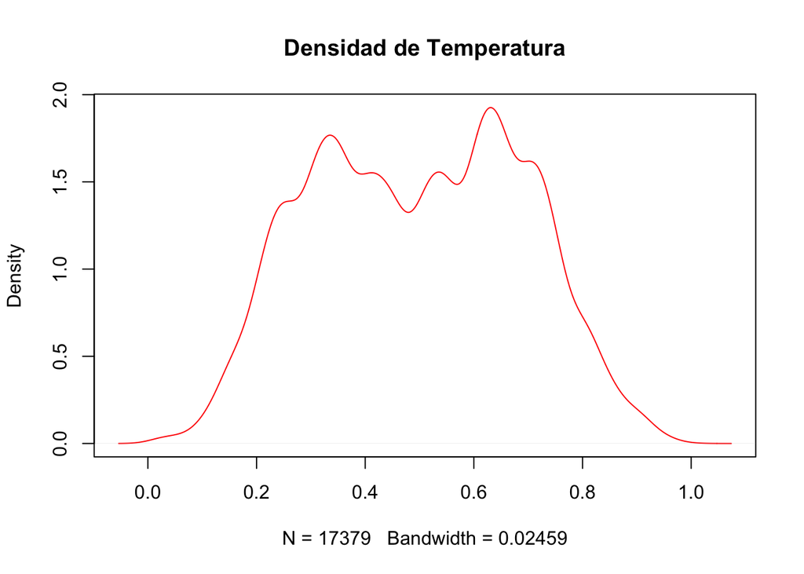

```r
plot(Sub7.density, main="Densidad de Temperatura", col = 'red')
```

## 8.- Con una gráfica explique en que temporada hubieron mas rentas de bicicletas.

```r
Sub8.dataset <- dataset %>%
  select(season, casual, registered, cnt) %>%
    mutate(Season = case_when(season == 1 ~ 'Spring',
        season == 2 ~ 'Summer',
        season == 3 ~ 'Fall',
        season == 4 ~ 'Winter')) %>%
      group_by(Season) %>%
        summarise(Casual = sum(casual), Registered = sum(registered), Total = sum(cnt) / 1000) %>%
          arrange(-Total)
Sub8.dataset
```

| Season | Casual | Registered | Total |
| --- | --- | --- | --- |
| Fall | 226091 | 835038 | 1061.129 |
| Summer | 203522 | 715067 | 918.589 |
| Winter | 129782 | 711831 | 841.613 |
| Spring | 60622 | 410726 | 471.348 |

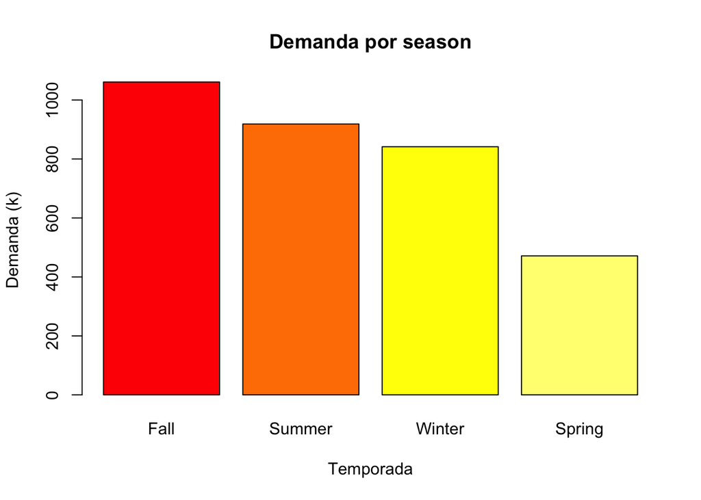

```r
barplot(Sub8.dataset$Total,
        main="Demanda por season",
        xlab="Temporada",
        ylab="Demanda (k)",
        col= heat.colors(nrow(Sub8.dataset)),
        names.arg = Sub8.dataset$Season)
```

## 9.- Con una gráfica, que temperatura en que temporada producen una mayor renta de bicicleteas (Hint: heatmap).

```r
Sub9.dataset <- dataset %>%
  select(temp, atemp, cnt, season) %>%
    mutate(Temp = round(((temp + atemp) / 2)*100) ) %>%
      mutate(Season = case_when(season == 1 ~ 'Spring',
            season == 2 ~ 'Summer',
            season == 3 ~ 'Fall',
            season == 4 ~ 'Winter')) %>%
        select(Temp, Season, Total = cnt) %>%
          arrange(Temp)
Sub9.dataset
```

| Temp | Season | Total |
| --- | --- | --- |
| 1 | Spring | 27 |
| 2 | Spring | 12 |
| 2 | Spring | 3 |
| 2 | Spring | 8 |
| 2 | Spring | 1 |
| 2 | Spring | 1 |
| 3 | Spring | 2 |
| 3 | Spring | 2 |
| 3 | Spring | 14 |
| 3 | Spring | 59 |

[output cut: 9990 more lines]

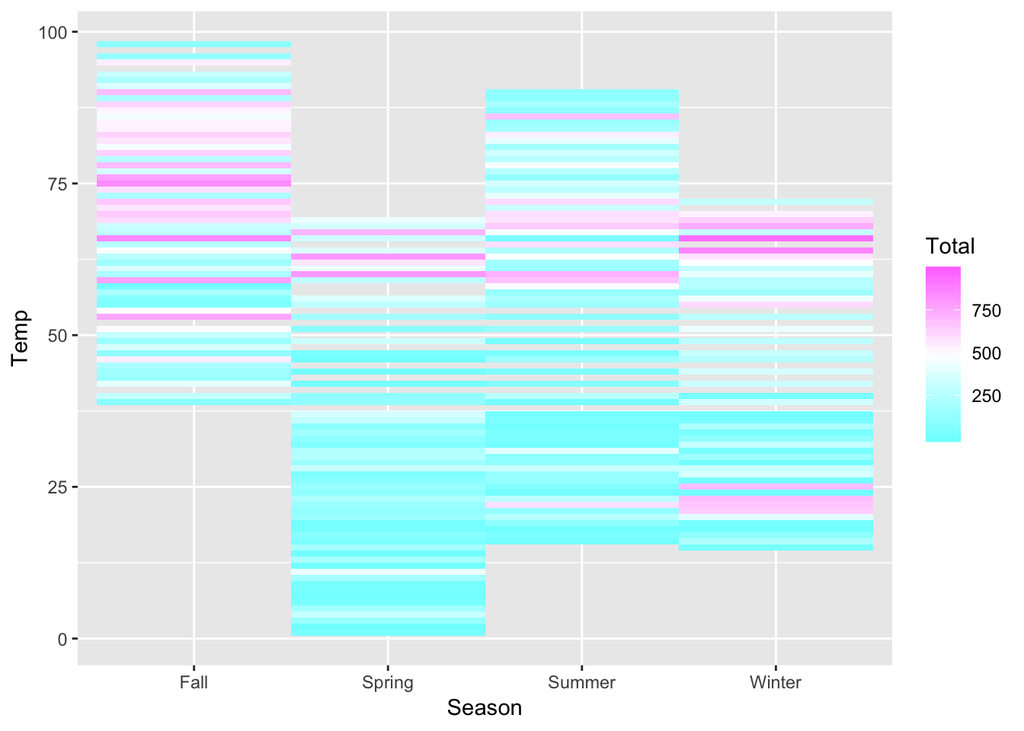

```r
ggplot(Sub9.dataset, aes(x = Season, y = Temp, fill = Total)) + geom_tile() + scale_fill_gradientn(colours = cm.colors(7))
```

## 10.- Muestre una gráfica de barras de día de la semana por bicicletas rentas, pero muestre en la misma barra cuantas rentas fueron por usuarios casuales y cuentas por usuarios registrados.

```r
Sub10.dataset <- dataset %>%
  select(dteday, casual, registered, cnt) %>%
    mutate(Date = weekdays(as.Date(dteday))) %>%
      select(Date, casual, registered, cnt) %>%
        group_by(Date) %>%
          summarise(Casual = sum (casual), Registered = sum(registered), Total = sum(cnt))

Sub10.dataset
```

| Date | Casual | Registered | Total |
| --- | --- | --- | --- |
| Friday | 78238 | 409552 | 487790 |
| Monday | 70784 | 384719 | 455503 |
| Saturday | 153852 | 323955 | 477807 |
| Sunday | 140521 | 303506 | 444027 |
| Thursday | 61460 | 423935 | 485395 |
| Tuesday | 57843 | 411266 | 469109 |
| Wednesday | 57319 | 415729 | 473048 |

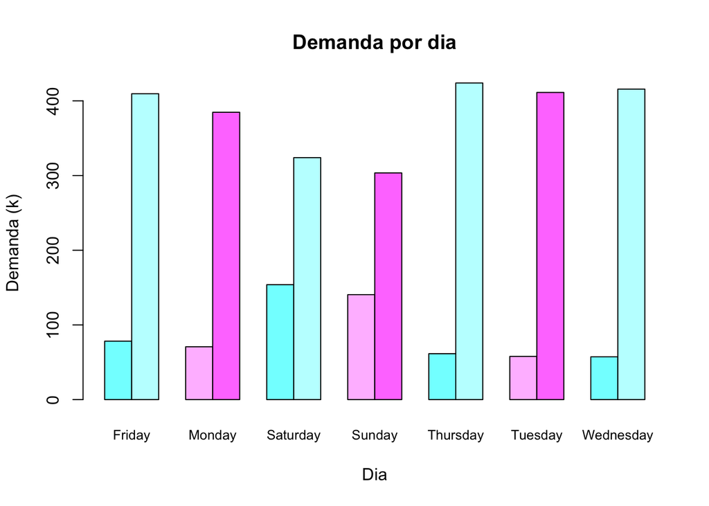

```r
data <- rbind(Sub10.dataset$Casual,Sub10.dataset$Registered)

barplot(data / 1000,
        main="Demanda por dia",
        xlab="Dia",
        ylab="Demanda (k)",
        col= cm.colors(nrow(Sub8.dataset)),
        names.arg = Sub10.dataset$Date,
        cex.names=0.8,
        beside=T)
```

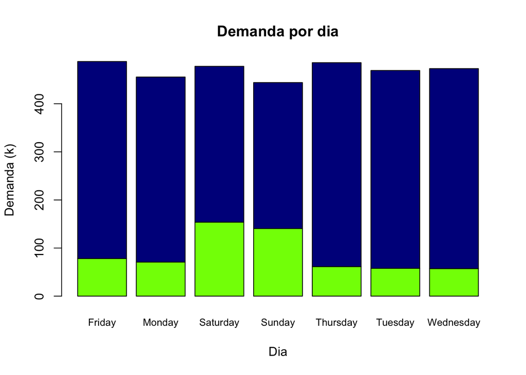

```r
barplot(data / 1000,
        main="Demanda por dia",
        xlab="Dia",
        ylab="Demanda (k)",
        col=c("chartreuse", "blue4"),
        cex.names=0.8,
        names.arg = Sub10.dataset$Date)
```